# Homework 1

jiaying Ning

9/23/2020

**Problem 1**

load packages

import data

1. Using the entire sample, provide descriptive statistics for all variables of interest.
1. Total sample size for each variable (N); Mean/SD, Median/IQR, Min and Max for continuous variables; Frequency/Percentages for categorical variables; Number of missing values for each variable. (8p)
2. Generate a his togram for the Ig-M values and comment on its shape. (2p)

since the only continuous variable is Antibody_Igm. We will be taking the descriptive statistics measure for this continuous variable.

below are its overall summary and desctiptive value table

```r
#overall summary
summary(Antibodies)
```

```
##     Subject       AgeCategory  Antibody_IgM                  Smell
##  Min.   :   1.0   18-30:318   Min.   :0.0480   Altered          :1047
##  1st Qu.: 632.5   31-50:810   1st Qu.:0.0690   Normal           : 410
##  Median :1373.0   51+  :363   Median :0.0915   Unanswered/Others:  34
##  Mean   :1413.8               Mean   :0.1239
##  3rd Qu.:2190.5               3rd Qu.:0.1290
##  Max.   :2917.0               Max.   :1.0475
##                               NA's   :1224
##     Gender
##  Female:981
##  Male  :510
##
##
##
##
##
```

```r
#print out the class table for each variable in the dataset
t(t(sapply(Antibodies, class)))
```

```
##              [,1]
## Subject      "integer"
## AgeCategory  "factor"
## Antibody_IgM "numeric"
## Smell        "factor"
## Gender       "factor"
```

```r
#print out the descriptive statistics
descriptivestats = summary(na.omit(Antibodies$Antibody_IgM))
descriptivestats
```

```
##    Min. 1st Qu.  Median    Mean 3rd Qu.    Max.
##  0.0480  0.0690  0.0915  0.1239  0.1290  1.0475
```

```r
IQR(na.omit(Antibodies$Antibody_IgM))
```

```
## [1] 0.06
```

```r
sd(na.omit(Antibodies$Antibody_IgM))
```

```
## [1] 0.1104458
```

From the dataset, I observe that only meaningful variable that is numeric is “Antibody_IgM”. Variable “AgeCategory”,“Smell”,“Gender” are all factor.

For continuous variable: Antibody_Igm has means of 0.1238839 with standard deviation of 0.1104458, median of 0.0915 and IQR of 0.06.Its min is 0.048 and max is 1.0475

For categorical variable the frequency and proportion of agegroup is:

```r
#frequency for categorical variable
##frequency of age category
table(Antibodies$AgeCategory)
```

```
##
## 18-30 31-50   51+
##   318   810   363
```

```r
prop.table(table(Antibodies$AgeCategory))
```

```
##
##     18-30     31-50       51+
## 0.2132797 0.5432596 0.2434608
```

the frequency and proportion of subject’s smell status is:

```r
##frequency of smell
table(Antibodies$Smell)
```

```
##
##           Altered            Normal Unanswered/Others
##              1047               410                34
```

```r
prop.table(table(Antibodies$Smell))
```

```
##
##           Altered            Normal Unanswered/Others
##        0.70221328        0.27498323        0.02280349
```

```r
##frequency of Gender
table(Antibodies$Gender)
```

```
##
## Female   Male
##    981    510
```

```r
prop.table(table(Antibodies$Gender))
```

```
##
##    Female      Male
## 0.6579477 0.3420523
```

From the summary table we know that there are 1224 NA values in Antibody_Igm variable. 34 unanswered/other in smell category.

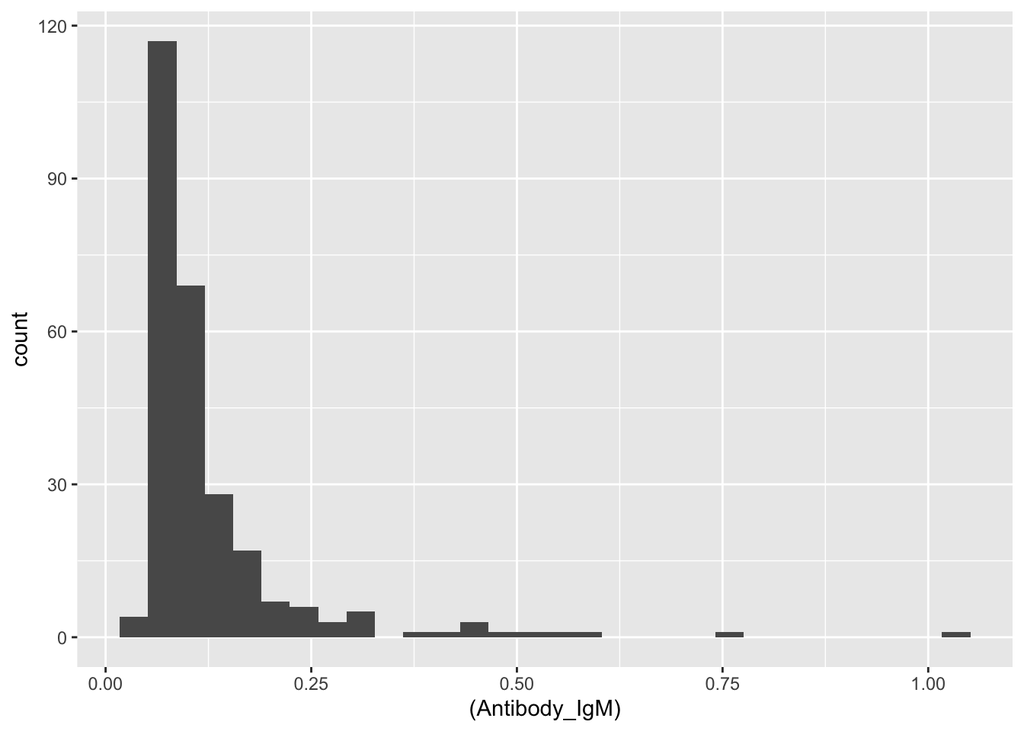

```r
ggplot(data=Antibodies,mapping=aes((Antibody_IgM))) + geom_histogram()
```

From the graph showing above, we can see that the distribution is skewing to the right. Most people have low antibody_igm.

**problem 2**

2. Provide descriptive statistics for all variables, stratified by smell category.
1. Provide descriptive statistics for all the other variables by the two smell categories (normal vs altered) and present them in a tabular form (see example below). Briefly comment on the differences observed between the two groups. (6p) Hint: tableby() in R can easily generate this, but feel free to create your own table in Word.

```r
library(dplyr)
library(furniture)

table1(Antibodies,AgeCategory,Subject,Antibody_IgM,Gender,splitby = "Smell",   row_wise = TRUE)
```

```
##
## ────────────────────────────────────────────────────────────
##                                 Smell
##               Altered       Normal        Unanswered/Others
##               n = 178       n = 81        n = 8
##  AgeCategory
##     18-30     36 (67.9%)    13 (24.5%)    4 (7.5%)
##     31-50     101 (68.2%)   43 (29.1%)    4 (2.7%)
##     51+       41 (62.1%)    25 (37.9%)    0 (0%)
##  Subject
##               585.9 (517.6) 622.9 (671.0) 722.4 (622.8)
##  Antibody_IgM
##               0.1 (0.1)     0.1 (0.1)     0.1 (0.1)
##  Gender
##     Female    120 (69%)     47 (27%)      7 (4%)
##     Male      58 (62.4%)    34 (36.6%)    1 (1.1%)
## ────────────────────────────────────────────────────────────
```

```r
Antibodies_clear = filter(Antibodies, Smell != "Unanswered/Others")
table1(Antibodies_clear,AgeCategory,Subject,Antibody_IgM,Gender,splitby = "Smell",   row_wise = TRUE)
```

```
##
## ──────────────────────────────────────────
##                        Smell
##               Altered       Normal
##               n = 178       n = 81
##  AgeCategory
##     18-30     36 (73.5%)    13 (26.5%)
##     31-50     101 (70.1%)   43 (29.9%)
##     51+       41 (62.1%)    25 (37.9%)
##  Subject
##               585.9 (517.6) 622.9 (671.0)
##  Antibody_IgM
##               0.1 (0.1)     0.1 (0.1)
##  Gender
##     Female    120 (71.9%)   47 (28.1%)
##     Male      58 (63%)      34 (37%)
## ──────────────────────────────────────────
```

Overall, more people reported having their smell altered than not. This difference in proportion is true among all age group and gender.

2. Use the Ig-M variable to generate side-by-side histograms and boxplots by smell categories

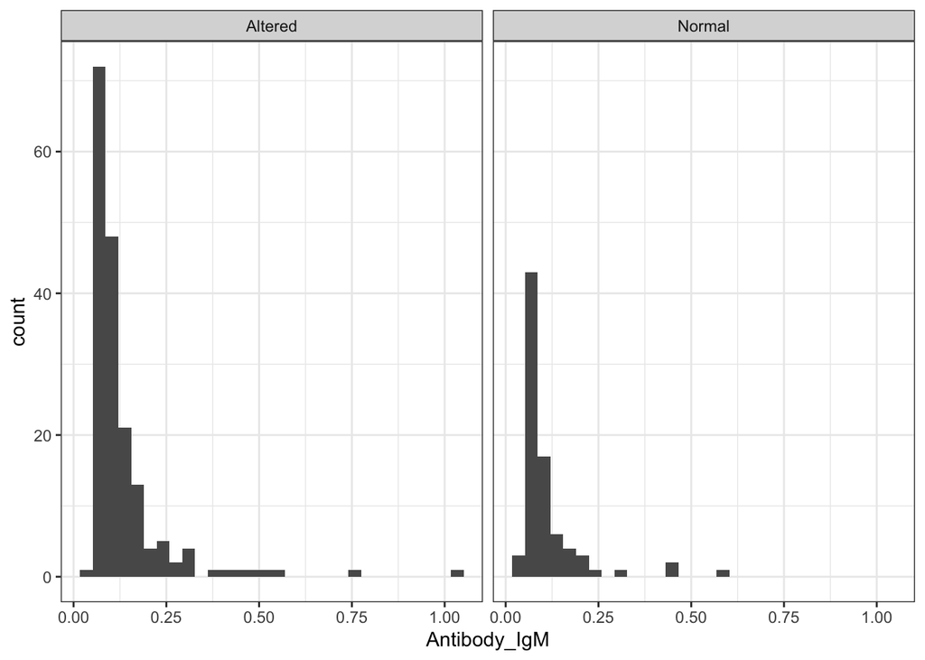

```r
ggplot(Antibodies_clear,aes(x=Antibody_IgM))+geom_histogram()+facet_grid(~Smell)+theme_bw()
```

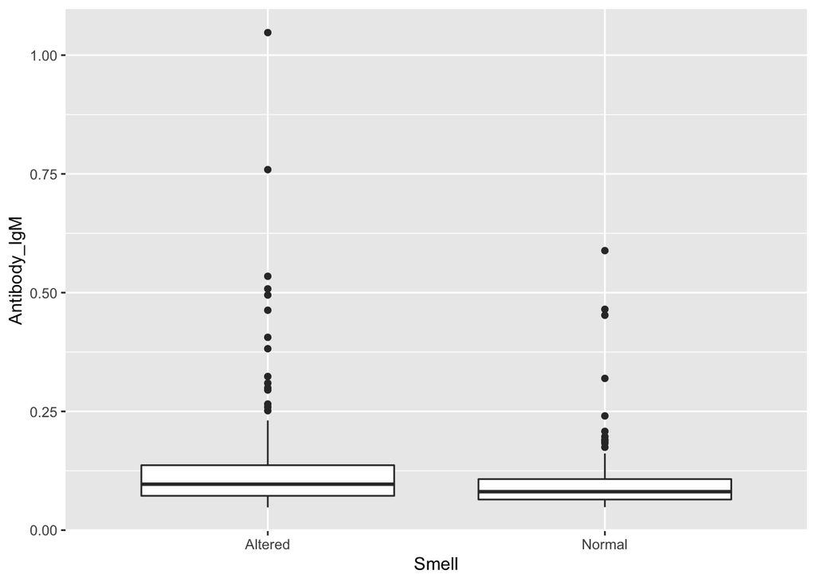

```r
ggplot(Antibodies_clear, aes(x=Smell, y=Antibody_IgM)) +
    geom_boxplot()
```